# Travel_Package_Purchase_Prediction_Final

## **Model performance improvement - Boosting**

```python
# Choose the type of classifier.
abc_tuned = AdaBoostClassifier(random_state=1)

# Grid of parameters to choose from
## add from article
parameters = {
    #Let's try different max_depth for base_estimator
    "base_estimator":[DecisionTreeClassifier(max_depth=1),DecisionTreeClassifier(max_depth=2),DecisionTreeClassifier(max_depth=3)],
    "n_estimators": np.arange(10,110,10),
    "learning_rate":np.arange(0.1,2,0.1)
}

# Type of scoring used to compare parameter combinations
acc_scorer = metrics.make_scorer(metrics.recall_score)

if no_grid_search:
  abc_tuned = AdaBoostClassifier(algorithm='SAMME.R',
                   base_estimator=DecisionTreeClassifier(ccp_alpha=0.0,
                                                         class_weight=None,
                                                         criterion='gini',
                                                         max_depth=3,
                                                         max_features=None,
                                                         max_leaf_nodes=None,
                                                         min_impurity_decrease=0.0,
                                                         min_impurity_split=None,
                                                         min_samples_leaf=1,
                                                         min_samples_split=2,
                                                         min_weight_fraction_leaf=0.0,
                                                         presort='deprecated',
                                                         random_state=None,
                                                         splitter='best'),
                   learning_rate=1.3000000000000003, n_estimators=80,
                   random_state=1)
else:
  # Run the grid search
  grid_obj = GridSearchCV(abc_tuned, parameters, scoring=acc_scorer,cv=5)
  grid_obj = grid_obj.fit(X_train, y_train)

  # Set the clf to the best combination of parameters
  abc_tuned = grid_obj.best_estimator_

# Fit the best algorithm to the data.
abc_tuned.fit(X_train, y_train)
```

```
AdaBoostClassifier(algorithm='SAMME.R',
                   base_estimator=DecisionTreeClassifier(ccp_alpha=0.0,
                                                         class_weight=None,
                                                         criterion='gini',
                                                         max_depth=3,
                                                         max_features=None,
                                                         max_leaf_nodes=None,
                                                         min_impurity_decrease=0.0,
                                                         min_impurity_split=None,
                                                         min_samples_leaf=1,
                                                         min_samples_split=2,
                                                         min_weight_fraction_leaf=0.0,
                                                         presort='deprecated',
                                                         random_state=None,
                                                         splitter='best'),
                   learning_rate=1.3000000000000003, n_estimators=80,
                   random_state=1)
```

```python
#Using above defined function to get accuracy, recall and precision on train and test set
abc_tuned_score=get_metrics_score(abc_tuned)
```

```
Accuracy on training set :  0.9792458345513008
Accuracy on test set :  0.8725289706884799
Recall on training set :  0.9208074534161491
Recall on test set :  0.6304347826086957
Precision on training set :  0.967373572593801
Precision on test set :  0.6718146718146718
```

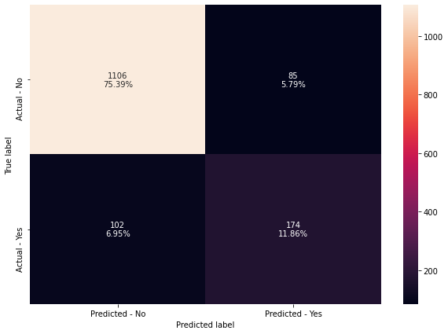

```python
make_confusion_matrix(abc_tuned,y_test)
```

**Insights**

1. With hyper parameters, overall performance improved when comparing to default one.
2. Model leans to training data than testing data.
3. Recall has been imporved when comparing to default.

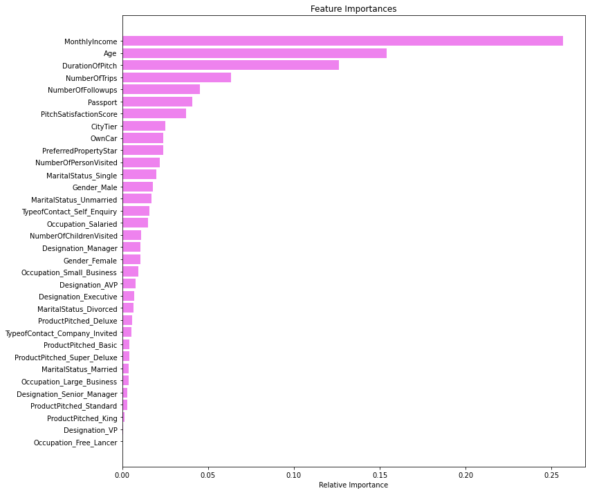

```python
importances = abc_tuned.feature_importances_
indices = np.argsort(importances)
feature_names = list(X.columns)

plt.figure(figsize=(12,12))
plt.title('Feature Importances')
plt.barh(range(len(indices)), importances[indices], color='violet', align='center')
plt.yticks(range(len(indices)), [feature_names[i] for i in indices])
plt.xlabel('Relative Importance')
plt.show()
```

## **Insights - Feature Importance ADA - Hyper**

1. Montly income is important feature to consider and it hold 25% in the decision
2. Age , Durationofpitch - are second most features to consider.
3. Number of Trips - helps to predict to prod taken in the fourth place.

# **Gradient Boosting Classifier Hyper tuning**

```python
gbc_init = GradientBoostingClassifier(init=AdaBoostClassifier(random_state=1),random_state=1)
gbc_init.fit(X_train,y_train)
```

```
GradientBoostingClassifier(ccp_alpha=0.0, criterion='friedman_mse',
                           init=AdaBoostClassifier(algorithm='SAMME.R',
                                                   base_estimator=None,
                                                   learning_rate=1.0,
                                                   n_estimators=50,
                                                   random_state=1),
                           learning_rate=0.1, loss='deviance', max_depth=3,
                           max_features=None, max_leaf_nodes=None,
                           min_impurity_decrease=0.0, min_impurity_split=None,
                           min_samples_leaf=1, min_samples_split=2,
                           min_weight_fraction_leaf=0.0, n_estimators=100,
                           n_iter_no_change=None, presort='deprecated',
                           random_state=1, subsample=1.0, tol=0.0001,
                           validation_fraction=0.1, verbose=0,
                           warm_start=False)
```

```python
#Using above defined function to get accuracy, recall and precision on train and test set
gbc_init_score=get_metrics_score(gbc_init)
```

```
Accuracy on training set :  0.8865828705057001
Accuracy on test set :  0.869120654396728
Recall on training set :  0.45652173913043476
Recall on test set :  0.39492753623188404
Precision on training set :  0.8855421686746988
Precision on test set :  0.8134328358208955
```

```python
# Choose the type of classifier.
gbc_tuned = GradientBoostingClassifier(init=AdaBoostClassifier(random_state=1),random_state=1)

# Grid of parameters to choose from
## add from article
parameters = {
    "n_estimators": [100,150,200,250],
    "subsample":[0.8,0.9,1],
    "max_features":[0.7,0.8,0.9,1]
}

# Type of scoring used to compare parameter combinations
acc_scorer = metrics.make_scorer(metrics.recall_score)

if no_grid_search:
  gbc_tuned = GradientBoostingClassifier(ccp_alpha=0.0, criterion='friedman_mse',
                           init=AdaBoostClassifier(algorithm='SAMME.R',
                                                   base_estimator=None,
                                                   learning_rate=1.0,
                                                   n_estimators=50,
                                                   random_state=1),
                           learning_rate=0.1, loss='deviance', max_depth=3,
                           max_features=0.8, max_leaf_nodes=None,
                           min_impurity_decrease=0.0, min_impurity_split=None,
                           min_samples_leaf=1, min_samples_split=2,
                           min_weight_fraction_leaf=0.0, n_estimators=250,
                           n_iter_no_change=None, presort='deprecated',
                           random_state=1, subsample=0.9, tol=0.0001,
                           validation_fraction=0.1, verbose=0,
                           warm_start=False)
else:
  # Run the grid search
  grid_obj = GridSearchCV(gbc_tuned, parameters, scoring=acc_scorer,cv=5)
  grid_obj = grid_obj.fit(X_train, y_train)

  # Set the clf to the best combination of parameters
  gbc_tuned = grid_obj.best_estimator_

# Fit the best algorithm to the data.
gbc_tuned.fit(X_train, y_train)
```

```
GradientBoostingClassifier(ccp_alpha=0.0, criterion='friedman_mse',
                           init=AdaBoostClassifier(algorithm='SAMME.R',
                                                   base_estimator=None,
                                                   learning_rate=1.0,
                                                   n_estimators=50,
                                                   random_state=1),
                           learning_rate=0.1, loss='deviance', max_depth=3,
                           max_features=0.8, max_leaf_nodes=None,
                           min_impurity_decrease=0.0, min_impurity_split=None,
                           min_samples_leaf=1, min_samples_split=2,
                           min_weight_fraction_leaf=0.0, n_estimators=250,
                           n_iter_no_change=None, presort='deprecated',
                           random_state=1, subsample=0.9, tol=0.0001,
                           validation_fraction=0.1, verbose=0,
                           warm_start=False)
```

```python
#Using above defined function to get accuracy, recall and precision on train and test set
gbc_tuned_score=get_metrics_score(gbc_tuned)
```

```
Accuracy on training set :  0.9219526454253142
Accuracy on test set :  0.8738922972051807
Recall on training set :  0.6257763975155279
Recall on test set :  0.45652173913043476
Precision on training set :  0.9393939393939394
Precision on test set :  0.782608695652174
```

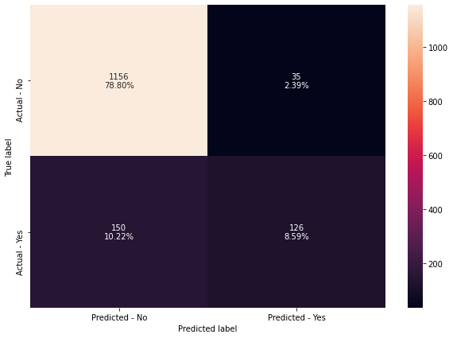

```python
make_confusion_matrix(gbc_tuned,y_test)
```

**Insights**

1. With hyper parameters, overall performance improved when comparing to default one.
2. Model leans to training data than testing data.
3. Recall has been imporved when comparing to default.

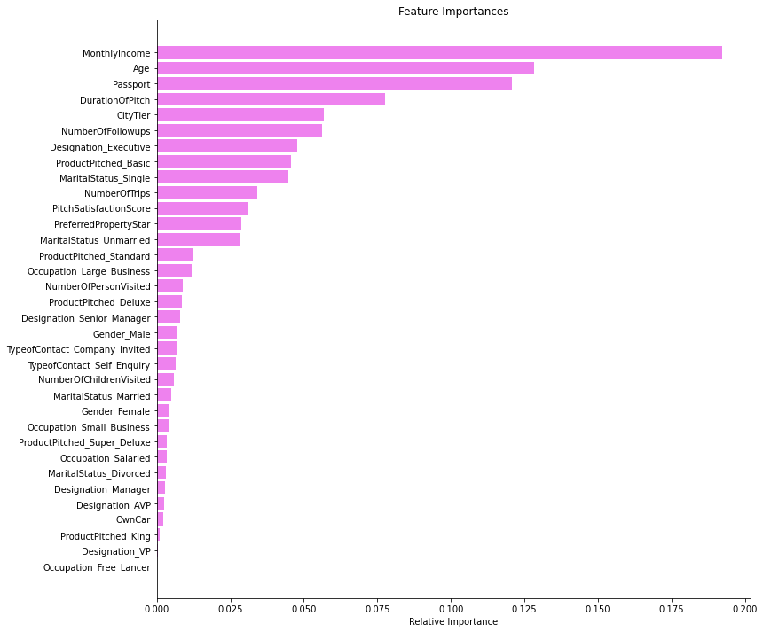

```python
importances = gbc_tuned.feature_importances_
indices = np.argsort(importances)
feature_names = list(X.columns)

plt.figure(figsize=(12,12))
plt.title('Feature Importances')
plt.barh(range(len(indices)), importances[indices], color='violet', align='center')
plt.yticks(range(len(indices)), [feature_names[i] for i in indices])
plt.xlabel('Relative Importance')
plt.show()
```

**Gradient Boosting Feature importance**

- Montly Income plays important role in this model to predict.
- Age , Passport and Duration of Pitch are next features which predict the outcome.

# **XGradient Boosting Tuned**

```python
# Choose the type of classifier.
xgb_tuned = XGBClassifier(random_state=1)

# Grid of parameters to choose from
## add from
parameters = {
    "n_estimators": np.arange(10,100,20),
    "scale_pos_weight":[0,1,2,5],
    "subsample":[0.5,0.7,0.9,1],
    "learning_rate":[0.01,0.1,0.2,0.05],
    "gamma":[0,1,3],
    "colsample_bytree":[0.5,0.7,0.9,1],
    "colsample_bylevel":[0.5,0.7,0.9,1]
}

# Type of scoring used to compare parameter combinations
acc_scorer = metrics.make_scorer(metrics.recall_score)

if no_grid_search:
  xgb_tuned = XGBClassifier(base_score=0.5, booster='gbtree', colsample_bylevel=0.5,
              colsample_bynode=1, colsample_bytree=0.5, gamma=0,
              learning_rate=0.01, max_delta_step=0, max_depth=3,
              min_child_weight=1, missing=None, n_estimators=70, n_jobs=1,
              nthread=None, objective='binary:logistic', random_state=1,
              reg_alpha=0, reg_lambda=1, scale_pos_weight=5, seed=None,
              silent=None, subsample=0.9, verbosity=1)
else:

  # Run the grid search
  grid_obj = GridSearchCV(xgb_tuned, parameters,scoring=acc_scorer,cv=5)
  grid_obj = grid_obj.fit(X_train, y_train)

  # Set the clf to the best combination of parameters
  xgb_tuned = grid_obj.best_estimator_

# Fit the best algorithm to the data.
xgb_tuned.fit(X_train, y_train)

# XGBClassifier(base_score=0.5, booster='gbtree', colsample_bylevel=0.5,
#               colsample_bynode=1, colsample_bytree=0.5, gamma=0,
#               learning_rate=0.01, max_delta_step=0, max_depth=3,
#               min_child_weight=1, missing=None, n_estimators=70, n_jobs=1,
#               nthread=None, objective='binary:logistic', random_state=1,
#               reg_alpha=0, reg_lambda=1, scale_pos_weight=5, seed=None,
#               silent=None, subsample=0.9, verbosity=1)
```

```
XGBClassifier(base_score=0.5, booster='gbtree', colsample_bylevel=0.5,
              colsample_bynode=1, colsample_bytree=0.5, gamma=0,
              learning_rate=0.01, max_delta_step=0, max_depth=3,
              min_child_weight=1, missing=None, n_estimators=70, n_jobs=1,
              nthread=None, objective='binary:logistic', random_state=1,
              reg_alpha=0, reg_lambda=1, scale_pos_weight=5, seed=None,
              silent=None, subsample=0.9, verbosity=1)
```

```python
#Using above defined function to get accuracy, recall and precision on train and test set
xgb_tuned_score=get_metrics_score(xgb_tuned)
```

```
Accuracy on training set :  0.7451037708272436
Accuracy on test set :  0.7416496250852079
Recall on training set :  0.7593167701863354
Recall on test set :  0.7789855072463768
Precision on training set :  0.4054726368159204
Precision on test set :  0.40337711069418386
```

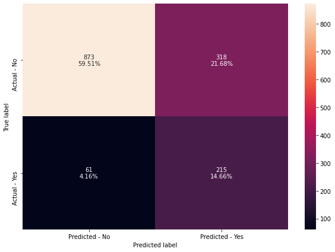

```python
make_confusion_matrix(xgb_tuned,y_test)
```

**Insights - XGradient Boosting**

1. Model has imporved performance when comparing with default of Xgradient.
2. Model does equal for training and testing data.

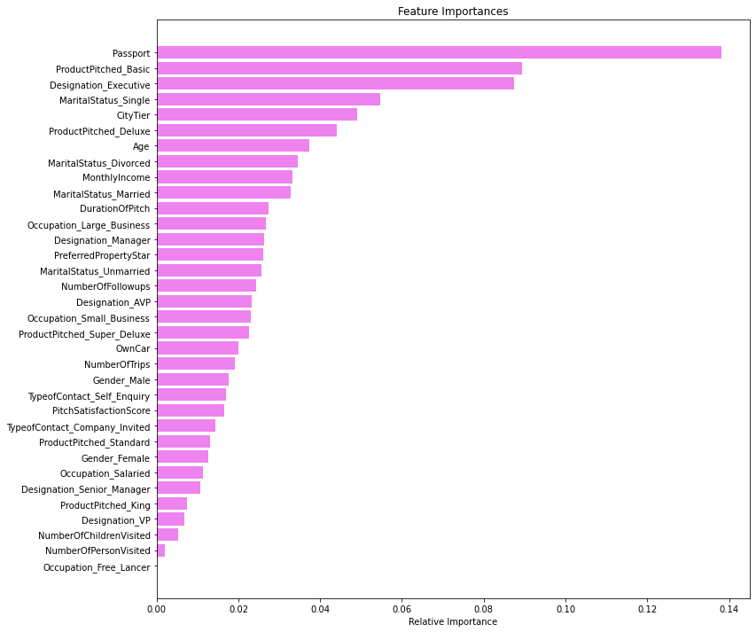

```python
importances = xgb_tuned.feature_importances_
indices = np.argsort(importances)
feature_names = list(X.columns)

plt.figure(figsize=(12,12))
plt.title('Feature Importances')
plt.barh(range(len(indices)), importances[indices], color='violet', align='center')
plt.yticks(range(len(indices)), [feature_names[i] for i in indices])
plt.xlabel('Relative Importance')
plt.show()
```

## **Insight Model performance improvement - Boosting**

With performance improvement, model are able to improve the prediction when comparing to the default.

Recall has been improved and data fitting equal to test and train data

## **Model performance evaluation**

```python
# defining list of models
# models = [abc, abc_tuned, gbc, gbc_init, gbc_tuned, xgb, xgb_tuned]
models = [  abc_tuned, gbc, gbc_init, gbc_tuned,xgb, xgb_tuned]
# defining empty lists to add train and test results
acc_train = []
acc_test = []
recall_train = []
recall_test = []
precision_train = []
precision_test = []

# looping through all the models to get the accuracy, precall and precision scores
for model in models:
    j = get_metrics_score(model,False)
    acc_train.append(np.round(j[0],2))
    acc_test.append(np.round(j[1],2))
    recall_train.append(np.round(j[2],2))
    recall_test.append(np.round(j[3],2))
    precision_train.append(np.round(j[4],2))
    precision_test.append(np.round(j[5],2))
```

```python
boosting_comparison_frame = pd.DataFrame({'Model':['AdaBoost Tuned',
                                          'Gradient Boosting with default parameters','Gradient Boosting with init=AdaBoost',
                                          'Gradient Boosting Tuned','XGBoost with default parameters','XGBoost Tuned'],
                                          'Train_Accuracy': acc_train,'Test_Accuracy': acc_test,
                                          'Train_Recall':recall_train,'Test_Recall':recall_test,
                                          'Train_Precision':precision_train,'Test_Precision':precision_test})
boosting_comparison_frame
```

|  | Model | Train_Accuracy | Test_Accuracy | Train_Recall | Test_Recall | Train_Precision | Test_Precision |
| --- | --- | --- | --- | --- | --- | --- | --- |
| 0 | AdaBoost Tuned | 0.98 | 0.87 | 0.92 | 0.63 | 0.97 | 0.67 |
| 1 | Gradient Boosting with default parameters | 0.89 | 0.87 | 0.46 | 0.40 | 0.89 | 0.80 |
| 2 | Gradient Boosting with init=AdaBoost | 0.89 | 0.87 | 0.46 | 0.39 | 0.89 | 0.81 |
| 3 | Gradient Boosting Tuned | 0.92 | 0.87 | 0.63 | 0.46 | 0.94 | 0.78 |
| 4 | XGBoost with default parameters | 0.88 | 0.87 | 0.42 | 0.37 | 0.87 | 0.80 |
| 5 | XGBoost Tuned | 0.75 | 0.74 | 0.76 | 0.78 | 0.41 | 0.40 |

```python
# defining list of models
bagging_models = [bagging_estimator,bagging_estimator_tuned,bagging_lr,rf_estimator_tuned,rf_estimator_weighted]

# defining empty lists to add train and test results
acc_train = []
acc_test = []
recall_train = []
recall_test = []
precision_train = []
precision_test = []

# looping through all the models to get the accuracy, precall and precision scores
for model in bagging_models:
    j = get_metrics_score(model,False)
    acc_train.append(np.round(j[0],2))
    acc_test.append(np.round(j[1],2))
    recall_train.append(np.round(j[2],2))
    recall_test.append(np.round(j[3],2))
    precision_train.append(np.round(j[4],2))
    precision_test.append(np.round(j[5],2))
```

```python
bagging_comparison_frame = pd.DataFrame({'Model':['Bagging classifier with default parameters','Tuned Bagging Classifier',
                                        'Bagging classifier with base_estimator=LR','Random_Forest With Tuned','Random Forest Estimator Weighted'],
                                          'Train_Accuracy': acc_train,'Test_Accuracy': acc_test,
                                          'Train_Recall':recall_train,'Test_Recall':recall_test,
                                          'Train_Precision':precision_train,'Test_Precision':precision_test})
bagging_comparison_frame
```

|  | Model | Train_Accuracy | Test_Accuracy | Train_Recall | Test_Recall | Train_Precision | Test_Precision |
| --- | --- | --- | --- | --- | --- | --- | --- |
| 0 | Bagging classifier with default parameters | 0.99 | 0.90 | 0.97 | 0.57 | 1.00 | 0.88 |
| 1 | Tuned Bagging Classifier | 1.00 | 0.92 | 1.00 | 0.63 | 1.00 | 0.93 |
| 2 | Bagging classifier with base_estimator=LR | 0.84 | 0.83 | 0.19 | 0.15 | 0.76 | 0.67 |
| 3 | Random_Forest With Tuned | 0.91 | 0.87 | 0.54 | 0.41 | 0.96 | 0.85 |
| 4 | Random Forest Estimator Weighted | 0.91 | 0.88 | 0.70 | 0.55 | 0.81 | 0.73 |

```python
pd.concat([boosting_comparison_frame,bagging_comparison_frame]).reset_index().drop(columns='index')
```

|  | Model | Train_Accuracy | Test_Accuracy | Train_Recall | Test_Recall | Train_Precision | Test_Precision |
| --- | --- | --- | --- | --- | --- | --- | --- |
| 0 | AdaBoost Tuned | 0.98 | 0.87 | 0.92 | 0.63 | 0.97 | 0.67 |
| 1 | Gradient Boosting with default parameters | 0.89 | 0.87 | 0.46 | 0.40 | 0.89 | 0.80 |
| 2 | Gradient Boosting with init=AdaBoost | 0.89 | 0.87 | 0.46 | 0.39 | 0.89 | 0.81 |
| 3 | Gradient Boosting Tuned | 0.92 | 0.87 | 0.63 | 0.46 | 0.94 | 0.78 |
| 4 | XGBoost with default parameters | 0.88 | 0.87 | 0.42 | 0.37 | 0.87 | 0.80 |
| 5 | XGBoost Tuned | 0.75 | 0.74 | 0.76 | 0.78 | 0.41 | 0.40 |
| 6 | Bagging classifier with default parameters | 0.99 | 0.90 | 0.97 | 0.57 | 1.00 | 0.88 |
| 7 | Tuned Bagging Classifier | 1.00 | 0.92 | 1.00 | 0.63 | 1.00 | 0.93 |
| 8 | Bagging classifier with base_estimator=LR | 0.84 | 0.83 | 0.19 | 0.15 | 0.76 | 0.67 |
| 9 | Random_Forest With Tuned | 0.91 | 0.87 | 0.54 | 0.41 | 0.96 | 0.85 |
| 10 | Random Forest Estimator Weighted | 0.91 | 0.88 | 0.70 | 0.55 | 0.81 | 0.73 |

## **Insights of model performanace evaluation**

1. In tuned Bagging classifiers, model looks to over fit on training data
2. Bagging classfier does minimun on test Recall.
3. Boosting classfier with tuning has increased the recall score.
4. XGBoost tuned looks to be over all consistent model that can perform for imporved recall.

## **Actionable Insights & Recommendations**

1. Cost involved in running a campaign and contacting the right customers for the wellness tour is more important. Recall metrics needs to strengthened to get the more right prediction.
2. Independent Features like Passport, Pitching the right prodict and pitch time looks significant in overall above analysis.
3. As age increases from 20 towards 40+, product taken is decreasing. So Earlier the age is good. Also we saw 50+ product taken is increased significantly. So for wellness campaign if we target them it can produce good result.
4. Martial status singles are more interested in the taking product.
5. Number of Followups plays an important role in gaining customers. More customers are signed on 4 to 6 th follow up.
1. We assumed False Negative an important criteria to solve by giving more importance to Recall.
2. As Designation increases, the interest of tour decreases.
3. Montly income plays important role, income around 20000 are major people to take tour.
4. City Tier 1 are more contributor followed by Tier 3 and then Tier-2
5. Finally product piched - Basic has more popularity in entire product line. For wellness tour, if we adapt the cost associated as basic, it can be sell more.